# Annotation of virulence factors

Produced with bacannot pipeline

21 January 2022

# GCF_000931575.1 virulence report

## About

Virulence factors are molecules produced by bacteria that add effectiveness in their colonization ability of a niche, immunoevasion, immunosuppression and nutrition obtention from the host. In order to detect these molecules in the query genome its gene sequences were aligned against two databases:

1. [VFDB](http://www.mgc.ac.cn/VFs/main.htm);
   - VFDB is a comprehensive resource, created in 2004, of curated information about virulence factors of pathogenic bacteria. To date, it contains a 1080 virulence factors in its database, from >74 *bacteria genera*.
   - In this pipeline the VFDB nucleotide core dataset (A) was used for alignment.
2. [Victors](http://www.phidias.us/victors/).
   - Victors is a curated database which currently possesses 5296 virulence factors for 194 different pathogens including bacteria, viruses and parasites and is focused in proteins related to interactions pathogen-host.
   - Victors is a protein database, thus scanned with `BLASTp`.

### Prediction thresholds

All the predictions were passed through a user defined threshold for minimum coverage and identity:

- Min. Identity (%): `> 60`
- Min. Coverage (%): `> 80`

> The results used to create this report are under the directory called `virulence` in the output folder of the query GCF_000931575.1.

## VFDB

All virulence factors (from VFDB) that were found to have at least one gene in the query genome are summarized below. All of them are linked to the database for further investigations. A more detailed information about the virulence annotation with VFDB is given in Table 1. Additionally, Figure 1 summarizes the amount of annotated genes of each virulence factor. Information are always linked to the database to make investigations easier.

> The results are showed as: **VFDB virulence factor name (VFDB virulence factor ID)**.

### Summary

- Virulence factors found in the query genome:
  - [EF-Tu (VF0460)](http://www.mgc.ac.cn/cgi-bin/VFs/vfs.cgi?VFID=VF0460#VF0460)
  - [HMW1/HMW2 (VF0038)](http://www.mgc.ac.cn/cgi-bin/VFs/vfs.cgi?VFID=VF0038#VF0038)
  - [HhuA (VF0271)](http://www.mgc.ac.cn/cgi-bin/VFs/vfs.cgi?VFID=VF0271#VF0271)
  - [HitABC (VF0268)](http://www.mgc.ac.cn/cgi-bin/VFs/vfs.cgi?VFID=VF0268#VF0268)
  - [HxuABC (VF0269)](http://www.mgc.ac.cn/cgi-bin/VFs/vfs.cgi?VFID=VF0269#VF0269)
  - [LOS (CVF494)](http://www.mgc.ac.cn/cgi-bin/VFs/comp_gene.cgi?RID=VFG013236)
  - [LOS (CVF494)](http://www.mgc.ac.cn/cgi-bin/VFs/comp_gene.cgi?RID=VFG013242)
  - [LOS (CVF494)](http://www.mgc.ac.cn/cgi-bin/VFs/comp_gene.cgi?RID=VFG013248)
  - [LOS (CVF494)](http://www.mgc.ac.cn/cgi-bin/VFs/comp_gene.cgi?RID=VFG013254)
  - [LOS (CVF494)](http://www.mgc.ac.cn/cgi-bin/VFs/comp_gene.cgi?RID=VFG013265)
  - [LOS (CVF494)](http://www.mgc.ac.cn/cgi-bin/VFs/comp_gene.cgi?RID=VFG013271)
  - [LOS (CVF494)](http://www.mgc.ac.cn/cgi-bin/VFs/comp_gene.cgi?RID=VFG013276)
  - [LOS (CVF494)](http://www.mgc.ac.cn/cgi-bin/VFs/comp_gene.cgi?RID=VFG013281)
  - [LOS (CVF494)](http://www.mgc.ac.cn/cgi-bin/VFs/comp_gene.cgi?RID=VFG013286)
  - [LOS (CVF494)](http://www.mgc.ac.cn/cgi-bin/VFs/comp_gene.cgi?RID=VFG013292)
  - [LOS (CVF494)](http://www.mgc.ac.cn/cgi-bin/VFs/comp_gene.cgi?RID=VFG013299)
  - [LOS (CVF494)](http://www.mgc.ac.cn/cgi-bin/VFs/comp_gene.cgi?RID=VFG013315)
  - [LOS (CVF494)](http://www.mgc.ac.cn/cgi-bin/VFs/comp_gene.cgi?RID=VFG013321)
  - [LOS (CVF494)](http://www.mgc.ac.cn/cgi-bin/VFs/comp_gene.cgi?RID=VFG013327)
  - [LOS (CVF494)](http://www.mgc.ac.cn/cgi-bin/VFs/comp_gene.cgi?RID=VFG013346)
  - [LOS (CVF494)](http://www.mgc.ac.cn/cgi-bin/VFs/comp_gene.cgi?RID=VFG013374)
  - [LOS (CVF494)](http://www.mgc.ac.cn/cgi-bin/VFs/comp_gene.cgi?RID=VFG013384)
  - [LOS (CVF494)](http://www.mgc.ac.cn/cgi-bin/VFs/comp_gene.cgi?RID=VFG013390)
  - [LOS (CVF494)](http://www.mgc.ac.cn/cgi-bin/VFs/comp_gene.cgi?RID=VFG013400)
  - [LOS (CVF494)](http://www.mgc.ac.cn/cgi-bin/VFs/comp_gene.cgi?RID=VFG013412)
  - [LOS (CVF494)](http://www.mgc.ac.cn/cgi-bin/VFs/comp_gene.cgi?RID=VFG013418)
  - [LOS (CVF494)](http://www.mgc.ac.cn/cgi-bin/VFs/comp_gene.cgi?RID=VFG013424)
  - [LOS (CVF494)](http://www.mgc.ac.cn/cgi-bin/VFs/comp_gene.cgi?RID=VFG013436)
  - [LOS (CVF494)](http://www.mgc.ac.cn/cgi-bin/VFs/comp_gene.cgi?RID=VFG013465)
  - [LOS (CVF494)](http://www.mgc.ac.cn/cgi-bin/VFs/comp_gene.cgi?RID=VFG013471)
  - [LOS (CVF494)](http://www.mgc.ac.cn/cgi-bin/VFs/comp_gene.cgi?RID=VFG013482)
  - [LOS (CVF494)](http://www.mgc.ac.cn/cgi-bin/VFs/comp_gene.cgi?RID=VFG013487)
  - [LOS (CVF494)](http://www.mgc.ac.cn/cgi-bin/VFs/comp_gene.cgi?RID=VFG013491)
  - [LOS (CVF494)](http://www.mgc.ac.cn/cgi-bin/VFs/comp_gene.cgi?RID=VFG013496)
  - [LOS (CVF494)](http://www.mgc.ac.cn/cgi-bin/VFs/comp_gene.cgi?RID=VFG013500)
  - [LOS (CVF494)](http://www.mgc.ac.cn/cgi-bin/VFs/comp_gene.cgi?RID=VFG013503)
  - [LOS (CVF494)](http://www.mgc.ac.cn/cgi-bin/VFs/comp_gene.cgi?RID=VFG013508)
  - [LOS (VF0044)](http://www.mgc.ac.cn/cgi-bin/VFs/vfs.cgi?VFID=VF0044#VF0044)
  - [OapA (VF0040)](http://www.mgc.ac.cn/cgi-bin/VFs/vfs.cgi?VFID=VF0040#VF0040)
  - [P2 protein (VF0042)](http://www.mgc.ac.cn/cgi-bin/VFs/vfs.cgi?VFID=VF0042#VF0042)
  - [P5 protein (VF0041)](http://www.mgc.ac.cn/cgi-bin/VFs/vfs.cgi?VFID=VF0041#VF0041)
  - [Tbp (VF0267)](http://www.mgc.ac.cn/cgi-bin/VFs/vfs.cgi?VFID=VF0267#VF0267)

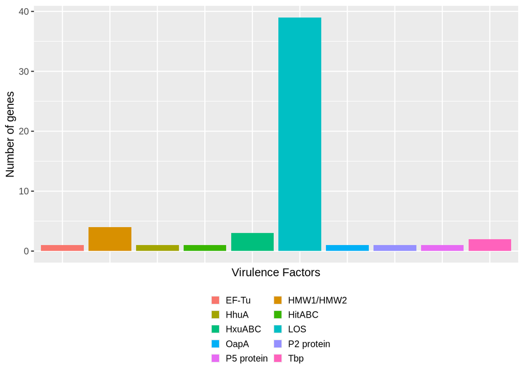

Figure 1: Virulence Factors annotated from [VFDB](http://www.mgc.ac.cn/VFs/main.htm) database

### Detailed information

Table 1: Virulence factors annotated using the VFDB database via BLASTn

| Virulence Factor Name | VF ID | Gene Name | Description | Query Protein ID | Query Protein Coordinates |
| --- | --- | --- | --- | --- | --- |
| LOS (CVF494) | VFG013286 | (galE) | VFG013286(gb\|NP_438515) (galE) UDP-glucose 4-epimerase [LOS (CVF494)] | IKKOIBFM_01394 | NZ_CP007470.1:1438550-1439566 |
| LOS (CVF494) | VFG013346 | (galU) | VFG013346(gb\|NP_438972) (galU) glucosephosphate uridylyltransferase [LOS (CVF494)] | IKKOIBFM_00891 | NZ_CP007470.1:928687-929574 |
| LOS (CVF494) | VFG013418 | (gmhA/lpcA) | VFG013418(gb\|NP_439337) (gmhA/lpcA) phosphoheptose isomerase [LOS (CVF494)] | IKKOIBFM_00556 | NZ_CP007470.1:571646-572230 |
| LOS (CVF494) | VFG013436 | (htrB) | VFG013436(gb\|NP_439676) (htrB) lipid A biosynthesis lauroyl acyltransferase [LOS (CVF494)] | IKKOIBFM_00127 | NZ_CP007470.1:138623-139558 |
| LOS (CVF494) | VFG013271 | (kdkA) | VFG013271(gb\|NP_438429) (kdkA) 3-deoxy-D-manno-octulosonic-acid kinase [LOS (CVF494)] | IKKOIBFM_01299 | NZ_CP007470.1:1349837-1350562 |
| LOS (CVF494) | VFG013465 | (kdsA) | VFG013465(gb\|NP_439706) (kdsA) 2-dehydro-3-deoxyphosphooctonate aldolase [LOS (CVF494)] | IKKOIBFM_00099 | NZ_CP007470.1:108058-108912 |
| LOS (CVF494) | VFG013236 | (kdsB) | VFG013236(gb\|NP_438231) (kdsB) 3-deoxy-manno-octulosonate cytidylyltransferase [LOS (CVF494)] | IKKOIBFM_01086 | NZ_CP007470.1:1119202-1119966 |
| LOS (CVF494) | VFG013471 | (lgtA) | VFG013471(gb\|NP_439724) (lgtA) N-acetylglucosamine glycosyltransferase [LOS (CVF494)] | IKKOIBFM_00078 | NZ_CP007470.1:91076-92047 |
| LOS (CVF494) | VFG013315 | (lgtF) | VFG013315(gb\|NP_438813) (lgtF) beta-1,4-glucosyltransferase [LOS (CVF494)] | IKKOIBFM_01752 | NZ_CP007470.1:1771076-1771840 |
| LOS (CVF494) | VFG013292 | (lic3A) | VFG013292(gb\|NP_438516) (lic3A) alpha-2,3-sialyltransferase [LOS (CVF494)] | IKKOIBFM_00838 | NZ_CP007470.1:873908-874612 |

[output cut: 44 more lines]

## Victors

All query genes predicted by Prokka that have a match in Victors database are described in Table 2. In order to make further investigations easier, all genes are linked to its matches in Victors database.

> Victors database is protein-only thus genes are scanned via blastp. Victors is a new database and focused in proteins that are important in the interaction pathogen-host, thus it may contain some less known genes.

Table 2: Virulence factors annotated using the Victors database via BLASTp

| Query Protein ID | Gene Name | Product | Description | Database ID | Query Protein Coordinates |
| --- | --- | --- | --- | --- | --- |
| IKKOIBFM_00007 | prfC from Actinobacillus pleuropneumoniae serovar 3 str. JL03 | peptide chain release factor 3 | gi\|165975488\|ref\|YP_001651081.1\| peptide chain release factor 3 [Actinobacillus pleuropneumoniae serovar 3 str. JL03] | 4120 | NZ_CP007470.1:5046-6626 |
| IKKOIBFM_00014 | argG from Actinobacillus pleuropneumoniae L20 | argininosuccinate synthase | gi\|126207906\|ref\|YP_001053131.1\| argininosuccinate synthase [Actinobacillus pleuropneumoniae serovar 5b str. L20] | 4053 | NZ_CP007470.1:13589-14923 |
| IKKOIBFM_00019 | map from Escherichia coli O157:H7 str. EDL933 | methionine aminopeptidase | gi\|15799850\|ref\|NP_285862.1\| methionine aminopeptidase [Escherichia coli O157:H7 str. EDL933] | 2125 | NZ_CP007470.1:19311-20117 |
| IKKOIBFM_00027 | ptsI from Haemophilus influenzae Rd KW20 | phosphoenolpyruvate-protein phosphotransferase | gi\|16273599\|ref\|NP_439854.1\| phosphoenolpyruvate-protein phosphotransferase [Haemophilus influenzae Rd KW20] | 2871 | NZ_CP007470.1:26507-28234 |
| IKKOIBFM_00037 | metH | 5-methyltetrahydropteroyltriglutamate--homocysteine methyltransferase | gi\|15676837\|ref\|NP_273982.1\| 5-methyltetrahydropteroyltriglutamate/homocysteine S-methyltransferase [Neisseria meningitidis MC58] | 3000 | NZ_CP007470.1:38032-40302 |
| IKKOIBFM_00050 | nth from Burkholderia pseudomallei K96243 | endonuclease III | gi\|53718738\|ref\|YP_107724.1\| endonuclease III [Burkholderia pseudomallei K96243] | 2005 | NZ_CP007470.1:52208-52843 |
| IKKOIBFM_00069 | aroA from Actinobacillus pleuropneumoniae L20 | 3-phosphoshikimate 1-carboxyvinyltransferase | gi\|126208179\|ref\|YP_001053404.1\| 3-phosphoshikimate 1-carboxyvinyltransferase [Actinobacillus pleuropneumoniae serovar 5b str. L20] | 4036 | NZ_CP007470.1:80372-81670 |
| IKKOIBFM_00073 | ilvI from Actinobacillus pleuropneumoniae serovar 3 str. JL03 | acetolactate synthase 3 catalytic subunit | gi\|165976143\|ref\|YP_001651736.1\| acetolactate synthase 3 catalytic subunit [Actinobacillus pleuropneumoniae serovar 3 str. JL03] | 4144 | NZ_CP007470.1:85210-86931 |
| IKKOIBFM_00109 | aroG from Neisseria meningitidis alpha14 | phospho-2-dehydro-3-deoxyheptonate aldolase | gi\|254805657\|ref\|YP_003083878.1\| phospho-2-dehydro-3-deoxyheptonate aldolase [Neisseria meningitidis alpha14] | 3897 | NZ_CP007470.1:117863-118951 |
| IKKOIBFM_00160 | rplT from Francisella tularensis subsp. holarctica LVS | 50S ribosomal protein L20 | gi\|89256697\|ref\|YP_514059.1\| 50S ribosomal protein L20 [Francisella tularensis subsp. holarctica LVS] | 473 | NZ_CP007470.1:167680-168033 |

[output cut: 105 more lines]